# R Basic Statistics

## 통계

https://www.mathsisfun.com/data/standard-normal-distribution.html

### 두개의 skewed 구하기

Values 1 2 3 4 5 6 7 8  
Frequency 4 6 4 4 3 2 1 1

Values 1 4 6 8 9 10 11 12  
Frequency 1 1 2 3 4 4 5 5

```r
a = c(1, 2, 3, 4, 5, 6, 7, 8)
f = c(4, 6, 4, 4, 3, 2, 1, 1)
cat("median : ",median(rep(a, f)),'\n',
    "mean : ",sum(a*f)/sum(f))
```

```
median :  3
 mean :  3.44
```

```r
a = c(1, 4, 6, 8, 9, 10, 11, 12)
f = c(1, 1, 2, 3, 4, 4, 5, 5)
cat("median : ",median(rep(a, f)),'\n',
  "mean : ",sum(a*f)/sum(f))
```

```
median :  10
 mean :  9.28
```

### rage, the lower and upper quartiles

Points scored per game 3 6 7 10 11 13 30  
Frequency 2 1 2 3 1 1 1

```r
points = c( 3, 6, 7, 10, 11, 13, 30)
f = c(2, 1, 2, 3, 1, 1, 1)
a = rep(points, f)
cat("range : ", range(points),'\n',
    "the lower and upper quartiles : ", quantile(a))
```

```
range :  3 30
 the lower and upper quartiles :  3 6.5 10 10.5 30
```

### 루트, 제곱

```r
cat(sqrt(12.67),'\n',
    3.56^2)
```

```
3.559494
 12.6736
```

### 1,2,4,5,6,7 평균 분산 구하기

```r
a = c(1,2,4,5,6,7)
mean = sum(a)/length(a)
variance = sum((a-mean)^2)/length(a)
standardDeviation = sqrt(variance)
cat('Mean ',mean,'\n',
'Variance ',variance, '\n',
'Standard Deviation ',standardDeviation)
```

```
Mean  4.166667
 Variance  4.472222
 Standard Deviation  2.114763
```

### z-score 함수 구하기

표준 편차 상에 어떤 위치에 있는지 보여줌

95% of students at school are between 1.1m and 1.7m tall  
- mean = (1.1+1.7)/2 = 1.4  
- 1-standard deviation = (1.7-1.1)/4 = 0.15  
인경우 z score

```r
zscore <- function(x, pmin, pmax) {
        mu <- (pmax+pmin)/2
        sd <- (pmax-pmin)/4
        z  <- (x-mu)/sd
        return(z)
}
cat(zscore(1.85, 1.1, 1.7))
```

```
3
```

-> 3 시그마 위치에 있음

- 표준편차  
  숫자들의 퍼짐 정도  
  1, 2, 3 표준편차
  1. 표준편차 : 68%
  2. 표준편차 : 95%
  3. 표준편차 : 99%
- **표준 점수(Standard score) z-score**

  통계학적으로 정규분포를 만들고 개개의 경우가 표준편차상에 어떤 위치를 차지하는지를 보여주는 차원없는 수치 1 : 내가 집단 전체가 평균적으로 떨어진 만큼 떨어져 있다.

## 가설

http://math7.tistory.com/82

### 귀무가설, 대립가설

- 문제) 강아지의 평균수명은 13년 이라고 알려져 있다. 실제로 그러한지 알아고비위해, 검정하려고 하는데, 이때 귀무가설과 대림가설을 설정하라.  
  – H0 : u = 13  
  – H1 : u != 13

### 두 모집단인 경우

- 문제) 개와 고양이의 평균수명을 조사하였다. 두 집단의 평균 수명의 차이가 있는지 파악하기위해 검정하려 한다.  
  – H0 : u1 = u2  
  – H1 : u1 != u2

### 검정통계량

가설검정에서 사용하는 통계량  
- z 통계량 (정규분포) - t 통계량 (t 분포) - x^2 통계량 (x^2 분포) - F 통계량 (F분포)

### 기각역

- 기각역(유의수준) : 귀무가설이 옳아도 귀무가설을 탈락시키는 확률
- 채택역 (1-기각역) : 귀무가설을 채택할 확률
- 기각역 설정 방법
1. 양측검정 : 같다. 다르다. (알파/2)
2. 단측검정(좌측,우측) : 이하, 이상 (알파)

검정 통계량 구하기

```r
testS <- function(x, mean, mu, n){
  up = x-mean
  down = mu/sqrt(n)
  s = up / down
  return(s)
}
round(testS(310,300, 30, 25), digits =2)
```

```
[1] 1.67
```

### 중심극한정리

**(central limit theorem, 약자 CLT)**

동일한 확률분포를 가진 독립 확률 변수 n개의 평균의 분포는 n이 적당히 크다면 정규분포에 가까워진다

- 모집단의 분포가 어떠하든 표본평균에 대한 분포는 정규분포를 이룬다.
- 표본평균은 모집단 평균은처에 모이는 경향이 있다.
- 표본평균들의 표준편차는 모집단의 표준편차를 표본크기의 제곱근 으로 나눈 것이다.

표본의 크기 30 모집단의 표준편차 1.44

```r
1.44/sqrt(30)
```

```
[1] 0.2629068
```

표본이 클수록 표본평균들의 표준편차는 작아진다.

## 그래프

### 히스토그램

[figure not shown]

```r
library(sqldf)
sal = sqldf('select sal from emp')
sal$SAL[9] = 5600
sal
```

| SAL |
| --- |
| 800 |
| 1600 |
| 1250 |
| 2975 |
| 1250 |
| 2850 |
| 2450 |
| 3000 |
| 5600 |
| 1500 |

[output cut: 4 more lines]

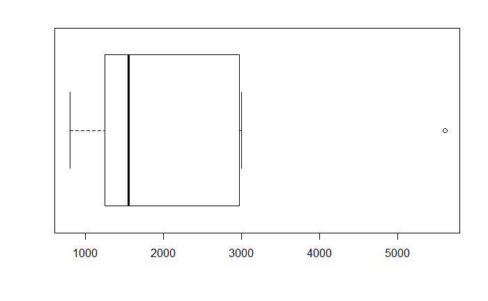

```r
boxplot(sal, width = 6000, horizontal=TRUE, outline = TRUE)
```

- 해석) Min – Lower Quartile[ Median ]Upper Quaritile – Max
  - 박스 IQR : Interquartile Range Q3 - Q1의 값 사분위 범위
- 통계적 추정  
  모집단으로부터 표본을 추출하고 추출된 표본의 통계량을 통해 모수를 추정
  - 점추정 : 하나의 점으로 값을 표현하는 것 (신뢰하기어려움)
  - 구간추정 : 점추정치를 중심으로 일정 구간을 만듬

### 신뢰구간 구하기

- 모 표준편차를 아는 경우 xbar(표본평균) n(표본개수) sigma(모 표준편차)

```r
confidence_interval_90 = function(xbar, n, sigma){
  low = xbar-(1.65*sigma/sqrt(n))
  hi = xbar+(1.65*sigma/sqrt(n))
  return(c(low, hi))
}
confidence_interval_95 = function(xbar, n, sigma){
  low = xbar-(1.96*sigma/sqrt(n))
  hi = xbar+(1.96*sigma/sqrt(n))
  return(c(low, hi))
}
confidence_interval_99 = function(xbar, n, sigma){
  low = xbar-(2.58*sigma/sqrt(n))
  hi = xbar+(2.58*sigma/sqrt(n))
  return(c(low, hi))
}
a = confidence_interval_90(800, 40, 100)
cat('90 : ', a[1],'< 800 < ',a[2],'\n')
```

```
90 :  773.9112 < 800 <  826.0888
```

```r
a = confidence_interval_95(800, 40, 100)
cat('95 : ', a[1],'< 800 < ',a[2],'\n')
```

```
95 :  769.0097 < 800 <  830.9903
```

```r
a = confidence_interval_99(800, 40, 100)
cat('99 : ', a[1],'< 800 < ',a[2],'\n')
```

```
99 :  759.2066 < 800 <  840.7934
```

- 모 표준편차를 모르는 경우
- 100명의 1주일 평균 공부 시간에 대한 95% 신뢰 구간  
  표본평균, 개수, 표본표준편차 (파라매터)

```r
confidence_interval_95 = function(xbar, n, sigma){
  low = xbar-(1.96*sigma/sqrt(n))
  up = xbar+(1.96*sigma/sqrt(n))
  return(c(low, up))
}
sd_interval_95 = function(m, n, d){
  low = m-(d/sqrt(n))*2
  up = m+(d/sqrt(n))*2
  return(c(low,up))
}
value = c(21, 20, 15)
m = mean(value)
d = sd(value)
m
```

```
[1] 18.66667
```

```r
d
```

```
[1] 3.21455
```

```r
ci = confidence_interval_95(m, 100, d)
si = sd_interval_95(m, 100, d)
cat('정규분포표를 이용 : ', ci[1],' ~ ',ci[2],'\n')
```

```
정규분포표를 이용 :  18.03661  ~  19.29672
```

```r
cat('표준편차와 평균을 이용 : ',si[1],' ~ ',si[2],'\n')
```

```
표준편차와 평균을 이용 :  18.02376  ~  19.30958
```

- 30명의 평균 수면 시간의 신뢰구간 95%

```r
value = c(7.5, 5, 6)
m = mean(value)
d = sd(value)
m
```

```
[1] 6.166667
```

```r
d
```

```
[1] 1.258306
```

```r
ci = confidence_interval_95(m, 30, d)
si = sd_interval_95(m, 30, d)
cat('정규분포표를 이용 : ', ci[1],' ~ ',ci[2],'\n')
```

```
정규분포표를 이용 :  5.716388  ~  6.616946
```

```r
cat('표준편차와 평균을 이용 : ',si[1],' ~ ',si[2],'\n')
```

```
표준편차와 평균을 이용 :  5.707198  ~  6.626135
```

- 가설검증 귀무가설 VS 대립가설
  1. 무작위로 뽑은 표본의 크기, 평균, 편차 추정표집분포를 만들고
  2. 추정표집분포의 중심점을 귀무가설이 예측한 위치(평균)로 민다.
  3. p value 확인 귀무가설이 맞을때 표본이 나올 수 있는 확률 0.05 이상이면 대립가설 지지율이 95% 가 안됨
- 표본평균 차이로 그룹 비교  
  두 그룹이 차이가 있는데 어느정도 차이가 있는지 알고 싶다.

  1)평균이 59.7 속도를 냄 표준편차 4.6  
  2)평균이 44.2 속도를 냄 표준편차 4.7 두 표본 평균의 차이를 중심에 두고  
  표준편차를 다르게 계산해서 (1로둠) 추정표집분포를 만듬

  표본평균들 간의 차를 계속 구해서 정규분포가 만들어짐

  신뢰수준 95%  
  1번 그룹이 2번 그룹보다 빠르다.
- 전체 모집단의 퍼짐정도 변동률  
  모집단의 표준편차, 분산
  - 카이제곱분포(x^2 분포) 데이터의 중심위치 파악  
    분산이 퍼져있는 모습을 분포로 만든것
  - F 분포 분산을 추정하고 검정할 때 사용하는 분포  
    두집단의 분산을 비교  
    ANOVA 3개 이상 집단의 분산을 비교하는것